# Excerpts re-typeset

## From the preprint of:

> Kissock, K., J. Haberl, and D. Claridge. 2003. Inverse Model Toolkit (RP-1050): Numerical algorithms for best-fit variable-base degree-day and change-point models. *ASHRAE Transactions* 109(2):425–34.

A related method is presented with signficant discrepancies in ASHRAE Guideline 14, Annex B.

A simplified method of estimating the uncertainty associated has been described by Reddy et al. (1998) and Kissock et al. (1998a). In this method, the energy savings, $Sav_i$, and the associated uncertainty, $\varepsilon_{si}$, for any data time interval $i$ in the post-retrofit period can be written as $$ Sav_i \pm \varepsilon_{si} = \left(\hat{Y}_i \pm \varepsilon_{pi}\right) -\left(Y_{mi} \pm \varepsilon_{mi}\right) $$ where $\hat{Y}_i$ is the energy consumption predicted by a pre-retrofit model, $Y_{mi}$ is the measured energy consumption during the post-retrofit period, and $\varepsilon$ is the random error associated with each parameter. The uncertainty $\varepsilon_{pi}$ of a predicted value of energy use, $\hat{Y}_i$, is (Neter et al. 1989) $$ \varepsilon_{pi} = t(1-\alpha/2, n-p)\cdot\mathrm{RMSE}\cdot \left[1 + \frac{1}{n} + \frac{\left(X_i-\bar{X}\right)^2}{ \sum_{i=1}^{n} \left(X_i - \bar{X}\right)^2} \right]^{\frac{1}{2}}, \quad (24) $$ where the t-statistic, $t(1-\alpha/2, n-p)$, is a function of the level of significance, $\alpha$, the number of [samples] in the pre-retrofit period, $n$, and the number of parameters in the model, $p$.

The level of significance, $\alpha$, indicates the fraction of predictions that are likely to fall outside of the prediction uncertainty bands. In practice, the value of the t-statistic is close to 1.96 for a reasonable number of pre-retrofit data points and a 5% significance (95% confidence) level. In addition, the value of the parenthetic term is usually very close to unity. Thus, $\varepsilon_{pi}$ can be closely approximated as $$ \varepsilon_{pi} \approx 1.96\, \mathrm{RMSE}\, (1 + 2/n)^{1/2}. \quad (25) $$

- Reddy. T.. J. Kissock. and D. Ruch. 1998. Uncertainty in baseline regression modeling and in determination of retrofit savings. *ASME Journal of Solar Energy Engineering* 120(3): 185- 192.
- Kissock. K.. A. Reddy. and D. Claridge. 1998a. Ambient temperature regression analysis for estimating retrofit savings in commercial buildings. *ASME Journal of Solar Energy Engineering* 120(3): 168- 176.
- Neter. J.. W. Wasserman. and M. Kutner. 1989. *Applied linear-regression models.* Boston. Mass.: Irwin Press.

## ECAM: formulas in BaseSumryOccElecMtr

For a single variable regression

Sample group $$ i \in \left\{\textrm{baseline period}\right\} $$

Residuals squared $$ \sum (y_i -\hat{y}_i)^2 $$

Root mean square error $$ RMSE = \sqrt \frac{\sum (y_i -\hat{y}_i)^2}{m-p} $$

Coefficient of determination $$ R^2 = 1 - \frac{ \sum (y_i -\hat{y}_i)^2 }{ \sum (y_i -\bar{y}_i)^2 } $$

Coefficient of variation of the root mean square error $$ CV(RMSE) = \frac{ \sqrt{ \frac{ \sum (y_i -\hat{y}_i)^2 }{ m - p } } }{ \bar{y} } $$

Fractional savings uncertainty (given assumed fractional savings and confidence interval, e.g. F=0.05 and confidence C=95%) [note 1], [note 2] $$ U = \frac{t}{|F|} \cdot (magic_1) \cdot CV(RMSE) \cdot \left( \frac{m}{m'} \cdot \left(1+\frac{2}{m'}\right) \cdot \frac{1}{n} \right)^{1/2}, \\ magic_1 = (-0.00024) (5.10684931477124)^2 + (0.03535)(5.10684931477124) + 1.00286 \\ \approx 1.17712794489546 $$

Critical t-statistic (using Excel notation for two-tailed distribution inverse): $$ t=\mathrm{T.INV.2T}(\alpha,m'-m), \\ \alpha = 1 - C $$

[Note 1]

Compare ASHRAE Guideline 14, eqn. 4-7. The derivation from 4-6 is skipped, but seems to be this: "Equation (14) involves matrix algebra and was simplified using numerical trials to within 10% accuracy" From Reddy, T.A., and D.E. Claridge. 2000. Uncertainty of “measured” energy savings from statistical baseline models. HVAC&R Research 6(1). Doi:10.1080/10789669.2000.10391247 (https://www.tandfonline.com/doi/abs/10.1080/10789669.2000.10391247)

[Note 2]

For this magic expression, see ECAM v6r5 source in module modrMandVformulas.FormulasAllSumryData2 at line 350, where it is referred to as the FSU factor. $$ magic = A\cdot months^2 + B\cdot months + C $$ If "NrmlzBillingData" flag is set, then A,B,C = (-0.00022,0.03306,0.94054), otherwise A,B,C = (-0.00024,0.03535,1.00286).

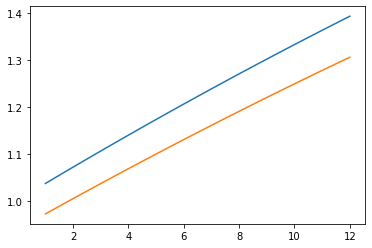

```python
import numpy as np
import matplotlib.pyplot as plt
x=np.linspace(1,12)
A,B,C=(-0.00024,0.03535,1.00286)
y1=A*x**2 + B*x + C
A,B,C = (-0.00022,0.03306,0.94054)
y2=A*x**2 + B*x + C
plt.plot(x,y1,x,y2)
plt.show()
plt.close()
```